# Telco Customer Churn Prediction

In this notebook, we will develop a machine learning model that can predict customers who will leave a company.

Before modeling, we will perform exploratory data analysis and feature engineering on the dataset.

The dataset contains various columns related to customer information for a telecommunications company, including demographic information, subscribed services, contract details, fees, and whether the customer has left (or discontinued) the company.

Variable Descriptions

# Importing necessary libraries and dataset

```python
import numpy as np
import pandas as pd
import seaborn as sns
from matplotlib import pyplot as plt
# !pip install missingno
import missingno as msno
from datetime import date
from sklearn.metrics import accuracy_score
from sklearn.model_selection import train_test_split
from sklearn.neighbors import LocalOutlierFactor
from sklearn.preprocessing import MinMaxScaler, LabelEncoder, StandardScaler, RobustScaler
from sklearn.neighbors import KNeighborsClassifier
from sklearn.svm import SVC
from sklearn.neural_network import MLPClassifier
from sklearn.tree import DecisionTreeClassifier
from sklearn.ensemble import RandomForestClassifier
from sklearn.ensemble import GradientBoostingClassifier
from xgboost import XGBClassifier
from lightgbm import LGBMClassifier
from catboost import CatBoostClassifier
from sklearn.linear_model import LogisticRegression
```

```python
df = pd.read_csv("WA_Fn-UseC_-Telco-Customer-Churn.csv")
df.head()
```

|  | customerID | gender | SeniorCitizen | Partner | Dependents | tenure | PhoneService | MultipleLines | InternetService | OnlineSecurity | ... | DeviceProtection | TechSupport | StreamingTV | StreamingMovies | Contract | PaperlessBilling | PaymentMethod | MonthlyCharges | TotalCharges | Churn |
| --- | --- | --- | --- | --- | --- | --- | --- | --- | --- | --- | --- | --- | --- | --- | --- | --- | --- | --- | --- | --- | --- |
| 0 | 7590-VHVEG | Female | 0 | Yes | No | 1 | No | No phone service | DSL | No | ... | No | No | No | No | Month-to-month | Yes | Electronic check | 29.85 | 29.85 | No |
| 1 | 5575-GNVDE | Male | 0 | No | No | 34 | Yes | No | DSL | Yes | ... | Yes | No | No | No | One year | No | Mailed check | 56.95 | 1889.5 | No |
| 2 | 3668-QPYBK | Male | 0 | No | No | 2 | Yes | No | DSL | Yes | ... | No | No | No | No | Month-to-month | Yes | Mailed check | 53.85 | 108.15 | Yes |
| 3 | 7795-CFOCW | Male | 0 | No | No | 45 | No | No phone service | DSL | Yes | ... | Yes | Yes | No | No | One year | No | Bank transfer (automatic) | 42.30 | 1840.75 | No |
| 4 | 9237-HQITU | Female | 0 | No | No | 2 | Yes | No | Fiber optic | No | ... | No | No | No | No | Month-to-month | Yes | Electronic check | 70.70 | 151.65 | Yes |

5 rows × 21 columns

# Exploratory Data Analysis

```python
def check_data(dataframe,head=5):
    print(20*"-" + "Information".center(20) + 20*"-")
    print(dataframe.info())
    print(20*"-" + "Data Shape".center(20) + 20*"-")
    print(dataframe.shape)
    print("\n" + 20*"-" + "The First 5 Data".center(20) + 20*"-")
    print(dataframe.head())
    print("\n" + 20 * "-" + "Missing Values".center(20) + 20 * "-")
    print(dataframe.isnull().sum())
    print("\n" + 40 * "-" + "Describe the Data".center(40) + 40 * "-")
    print(dataframe.describe([0.01, 0.05,0.10, 0.25, 0.50, 0.75, 0.90, 0.95, 0.99]).T)

check_data(df)
```

```
--------------------    Information     --------------------
<class 'pandas.core.frame.DataFrame'>
RangeIndex: 7043 entries, 0 to 7042
Data columns (total 21 columns):
 #   Column            Non-Null Count  Dtype
---  ------            --------------  -----
 0   customerID        7043 non-null   object
 1   gender            7043 non-null   object
 2   SeniorCitizen     7043 non-null   int64
 3   Partner           7043 non-null   object
 4   Dependents        7043 non-null   object
 5   tenure            7043 non-null   int64
 6   PhoneService      7043 non-null   object
 7   MultipleLines     7043 non-null   object
 8   InternetService   7043 non-null   object
 9   OnlineSecurity    7043 non-null   object
 10  OnlineBackup      7043 non-null   object
 11  DeviceProtection  7043 non-null   object
 12  TechSupport       7043 non-null   object
 13  StreamingTV       7043 non-null   object
 14  StreamingMovies   7043 non-null   object
 15  Contract          7043 non-null   object
 16  PaperlessBilling  7043 non-null   object
 17  PaymentMethod     7043 non-null   object
 18  MonthlyCharges    7043 non-null   float64
 19  TotalCharges      7043 non-null   object
 20  Churn             7043 non-null   object
dtypes: float64(1), int64(2), object(18)
memory usage: 1.1+ MB
None
--------------------     Data Shape     --------------------
(7043, 21)

--------------------  The First 5 Data  --------------------
   customerID  gender  SeniorCitizen Partner Dependents  tenure PhoneService  \
0  7590-VHVEG  Female              0     Yes         No       1           No
1  5575-GNVDE    Male              0      No         No      34          Yes
2  3668-QPYBK    Male              0      No         No       2          Yes
3  7795-CFOCW    Male              0      No         No      45           No
4  9237-HQITU  Female              0      No         No       2          Yes
```

[output cut: 43 more lines]

```
MonthlyCharges      0
TotalCharges        0
Churn               0
dtype: int64

----------------------------------------           Describe the Data            ----------------------------------------
                 count       mean        std    min    1%     5%    10%   25%  \
SeniorCitizen   7043.0   0.162147   0.368612   0.00   0.0   0.00   0.00   0.0
tenure          7043.0  32.371149  24.559481   0.00   1.0   1.00   2.00   9.0
MonthlyCharges  7043.0  64.761692  30.090047  18.25  19.2  19.65  20.05  35.5

                  50%    75%    90%    95%      99%     max
SeniorCitizen    0.00   0.00    1.0    1.0    1.000    1.00
tenure          29.00  55.00   69.0   72.0   72.000   72.00
MonthlyCharges  70.35  89.85  102.6  107.4  114.729  118.75
```

### Pre-Processing

```python
df['TotalCharges'] = pd.to_numeric(df['TotalCharges'], errors='coerce')

# Check for any new missing values in 'TotalCharges'
new_missing_values = df['TotalCharges'].isnull().sum()
new_missing_values
```

```
np.int64(11)
```

Converting the 'TotalCharges' column to a numeric format resulted in 11 new missing values. These likely correspond to instances in the original data containing non-numeric characters or empty strings that could not be converted into numbers.

We have several options for handling these missing values:

Remove Rows: If the dataset is sufficiently large, removing these 11 rows may not significantly impact the analysis.

Impute Values: We can fill these missing values using a statistic—such as the mean or median—or by deriving a value based on other columns (for example, by using 'MonthlyCharges' and 'Tenure' to estimate 'TotalCharges').

Investigate Further: Before making a decision, we may wish to examine these specific rows to understand why the values are missing.

```python
# Display the rows with missing values in 'TotalCharges'
missing_total_charges_rows = df[df['TotalCharges'].isnull()]
missing_total_charges_rows
```

|  | customerID | gender | SeniorCitizen | Partner | Dependents | tenure | PhoneService | MultipleLines | InternetService | OnlineSecurity | ... | DeviceProtection | TechSupport | StreamingTV | StreamingMovies | Contract | PaperlessBilling | PaymentMethod | MonthlyCharges | TotalCharges | Churn |
| --- | --- | --- | --- | --- | --- | --- | --- | --- | --- | --- | --- | --- | --- | --- | --- | --- | --- | --- | --- | --- | --- |
| 488 | 4472-LVYGI | Female | 0 | Yes | Yes | 0 | No | No phone service | DSL | Yes | ... | Yes | Yes | Yes | No | Two year | Yes | Bank transfer (automatic) | 52.55 | NaN | No |
| 753 | 3115-CZMZD | Male | 0 | No | Yes | 0 | Yes | No | No | No internet service | ... | No internet service | No internet service | No internet service | No internet service | Two year | No | Mailed check | 20.25 | NaN | No |
| 936 | 5709-LVOEQ | Female | 0 | Yes | Yes | 0 | Yes | No | DSL | Yes | ... | Yes | No | Yes | Yes | Two year | No | Mailed check | 80.85 | NaN | No |
| 1082 | 4367-NUYAO | Male | 0 | Yes | Yes | 0 | Yes | Yes | No | No internet service | ... | No internet service | No internet service | No internet service | No internet service | Two year | No | Mailed check | 25.75 | NaN | No |
| 1340 | 1371-DWPAZ | Female | 0 | Yes | Yes | 0 | No | No phone service | DSL | Yes | ... | Yes | Yes | Yes | No | Two year | No | Credit card (automatic) | 56.05 | NaN | No |
| 3331 | 7644-OMVMY | Male | 0 | Yes | Yes | 0 | Yes | No | No | No internet service | ... | No internet service | No internet service | No internet service | No internet service | Two year | No | Mailed check | 19.85 | NaN | No |
| 3826 | 3213-VVOLG | Male | 0 | Yes | Yes | 0 | Yes | Yes | No | No internet service | ... | No internet service | No internet service | No internet service | No internet service | Two year | No | Mailed check | 25.35 | NaN | No |
| 4380 | 2520-SGTTA | Female | 0 | Yes | Yes | 0 | Yes | No | No | No internet service | ... | No internet service | No internet service | No internet service | No internet service | Two year | No | Mailed check | 20.00 | NaN | No |
| 5218 | 2923-ARZLG | Male | 0 | Yes | Yes | 0 | Yes | No | No | No internet service | ... | No internet service | No internet service | No internet service | No internet service | One year | Yes | Mailed check | 19.70 | NaN | No |
| 6670 | 4075-WKNIU | Female | 0 | Yes | Yes | 0 | Yes | Yes | DSL | No | ... | Yes | Yes | Yes | No | Two year | No | Mailed check | 73.35 | NaN | No |
| 6754 | 2775-SEFEE | Male | 0 | No | Yes | 0 | Yes | Yes | DSL | Yes | ... | No | Yes | No | No | Two year | Yes | Bank transfer (automatic) | 61.90 | NaN | No |

11 rows × 21 columns

```python
df['TotalCharges'].fillna(0, inplace=True)
```

```python
df.isnull().sum()
```

```
customerID          0
gender              0
SeniorCitizen       0
Partner             0
Dependents          0
tenure              0
PhoneService        0
MultipleLines       0
InternetService     0
OnlineSecurity      0
OnlineBackup        0
DeviceProtection    0
TechSupport         0
StreamingTV         0
StreamingMovies     0
Contract            0
PaperlessBilling    0
PaymentMethod       0
MonthlyCharges      0
TotalCharges        0
Churn               0
dtype: int64
```

Since CustomerID is likely a unique identifier for each customer and may not contribute to aggregate data analysis, we could either keep it for identification purposes or remove it if it's not needed for the analysis.

```python
df.drop('customerID', axis=1, inplace=True)

# Display the first few rows of the dataset to confirm the drop
df.head()
```

|  | gender | SeniorCitizen | Partner | Dependents | tenure | PhoneService | MultipleLines | InternetService | OnlineSecurity | OnlineBackup | DeviceProtection | TechSupport | StreamingTV | StreamingMovies | Contract | PaperlessBilling | PaymentMethod | MonthlyCharges | TotalCharges | Churn |
| --- | --- | --- | --- | --- | --- | --- | --- | --- | --- | --- | --- | --- | --- | --- | --- | --- | --- | --- | --- | --- |
| 0 | Female | 0 | Yes | No | 1 | No | No phone service | DSL | No | Yes | No | No | No | No | Month-to-month | Yes | Electronic check | 29.85 | 29.85 | No |
| 1 | Male | 0 | No | No | 34 | Yes | No | DSL | Yes | No | Yes | No | No | No | One year | No | Mailed check | 56.95 | 1889.50 | No |
| 2 | Male | 0 | No | No | 2 | Yes | No | DSL | Yes | Yes | No | No | No | No | Month-to-month | Yes | Mailed check | 53.85 | 108.15 | Yes |
| 3 | Male | 0 | No | No | 45 | No | No phone service | DSL | Yes | No | Yes | Yes | No | No | One year | No | Bank transfer (automatic) | 42.30 | 1840.75 | No |
| 4 | Female | 0 | No | No | 2 | Yes | No | Fiber optic | No | No | No | No | No | No | Month-to-month | Yes | Electronic check | 70.70 | 151.65 | Yes |

We will perform Exploratory Data Analysis (EDA) on the dataset. EDA is a crucial step in data analysis, as it helps us understand the distribution, trends, and relationships within the data. Here is our plan for the EDA:

1. **Summary Statistics:** We will begin with basic summary statistics for the numerical columns.
2. **Variable Distribution:** Analyze the distribution of key variables—both numerical (such as "tenure," "MonthlyCharges," and "TotalCharges") and categorical (such as "gender," "InternetService," and "Contract").
3. **Correlation Analysis:** Examine the correlations between numerical variables.
4. **Churn Analysis:** Since the target variable is "Churn," we will specifically focus on how different variables relate to the rate of subscriber attrition.
5. **Visualizations:** We will use various charts (such as histograms, bar charts, box plots, and scatter plots) to visualize the data and uncover patterns.

## Summary Statistics

```python
def grab_col_names(dataframe, cat_th=10, car_th=20):

   # cat_cols, cat_but_car
    cat_cols = [col for col in dataframe.columns if dataframe[col].dtypes == "O"]
    num_but_cat = [col for col in dataframe.columns if dataframe[col].nunique() < cat_th and
                   dataframe[col].dtypes != "O"]
    cat_but_car = [col for col in dataframe.columns if dataframe[col].nunique() > car_th and
                   dataframe[col].dtypes == "O"]
    cat_cols = cat_cols + num_but_cat
    cat_cols = [col for col in cat_cols if col not in cat_but_car]

    # num_cols
    num_cols = [col for col in dataframe.columns if dataframe[col].dtypes != "O"]
    num_cols = [col for col in num_cols if col not in num_but_cat]

    print(f"Observations: {dataframe.shape[0]}")
    print(f"Variables: {dataframe.shape[1]}")
    print(f'cat_cols: {len(cat_cols)}')
    print(f'num_cols: {len(num_cols)}')
    print(f'cat_but_car: {len(cat_but_car)}')
    print(f'num_but_cat: {len(num_but_cat)}')
    return cat_cols, num_cols, cat_but_car

cat_cols, num_cols, cat_but_car = grab_col_names(df)
```

```
Observations: 7043
Variables: 20
cat_cols: 17
num_cols: 3
cat_but_car: 0
num_but_cat: 1
```

## Numeric Variables

```python
num_cols
```

```
['tenure', 'MonthlyCharges', 'TotalCharges']
```

```python
df[num_cols].describe().T
```

|  | count | mean | std | min | 25% | 50% | 75% | max |
| --- | --- | --- | --- | --- | --- | --- | --- | --- |
| tenure | 7043.0 | 32.371149 | 24.559481 | 0.00 | 9.00 | 29.00 | 55.00 | 72.00 |
| MonthlyCharges | 7043.0 | 64.761692 | 30.090047 | 18.25 | 35.50 | 70.35 | 89.85 | 118.75 |
| TotalCharges | 7043.0 | 2279.734304 | 2266.794470 | 0.00 | 398.55 | 1394.55 | 3786.60 | 8684.80 |

## Categorical Variables

```python
cat_cols
```

```
['gender',
 'Partner',
 'Dependents',
 'PhoneService',
 'MultipleLines',
 'InternetService',
 'OnlineSecurity',
 'OnlineBackup',
 'DeviceProtection',
 'TechSupport',
 'StreamingTV',
 'StreamingMovies',
 'Contract',
 'PaperlessBilling',
 'PaymentMethod',
 'Churn',
 'SeniorCitizen']
```

```python
df[cat_cols].describe(include=["object"])
```

|  | gender | Partner | Dependents | PhoneService | MultipleLines | InternetService | OnlineSecurity | OnlineBackup | DeviceProtection | TechSupport | StreamingTV | StreamingMovies | Contract | PaperlessBilling | PaymentMethod | Churn |
| --- | --- | --- | --- | --- | --- | --- | --- | --- | --- | --- | --- | --- | --- | --- | --- | --- |
| count | 7043 | 7043 | 7043 | 7043 | 7043 | 7043 | 7043 | 7043 | 7043 | 7043 | 7043 | 7043 | 7043 | 7043 | 7043 | 7043 |
| unique | 2 | 2 | 2 | 2 | 3 | 3 | 3 | 3 | 3 | 3 | 3 | 3 | 3 | 2 | 4 | 2 |
| top | Male | No | No | Yes | No | Fiber optic | No | No | No | No | No | No | Month-to-month | Yes | Electronic check | No |
| freq | 3555 | 3641 | 4933 | 6361 | 3390 | 3096 | 3498 | 3088 | 3095 | 3473 | 2810 | 2785 | 3875 | 4171 | 2365 | 5174 |

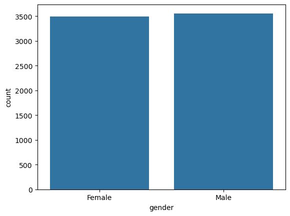

```
        gender     Ratio
gender
Male      3555  50.47565
Female    3488  49.52435
##########################################
```

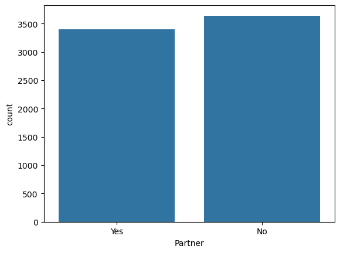

```
         Partner     Ratio
Partner
No          3641  51.69672
Yes         3402  48.30328
##########################################
```

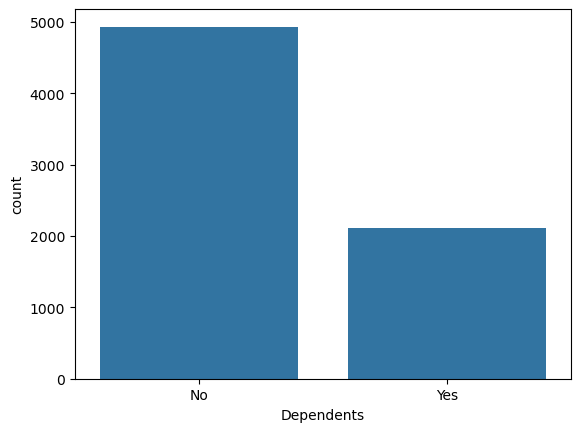

```
            Dependents      Ratio
Dependents
No                4933  70.041176
Yes               2110  29.958824
##########################################
```

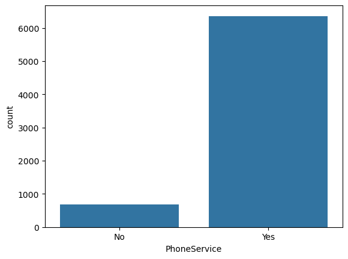

```
              PhoneService      Ratio
PhoneService
Yes                   6361  90.316626
No                     682   9.683374
##########################################
```

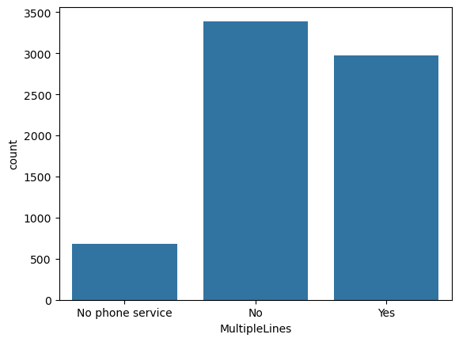

```
                  MultipleLines      Ratio
MultipleLines
No                         3390  48.132898
Yes                        2971  42.183729
No phone service            682   9.683374
##########################################
```

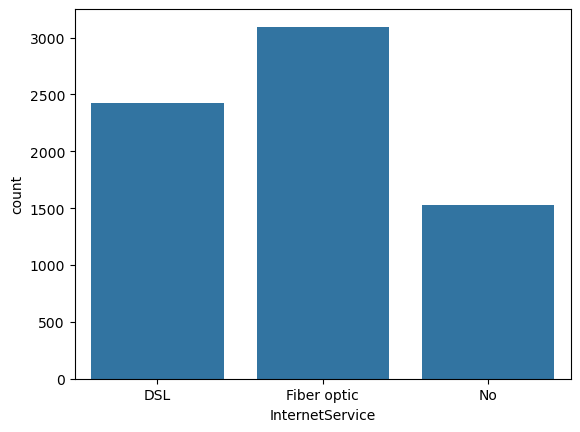

```
                 InternetService      Ratio
InternetService
Fiber optic                 3096  43.958540
DSL                         2421  34.374556
No                          1526  21.666903
##########################################
```

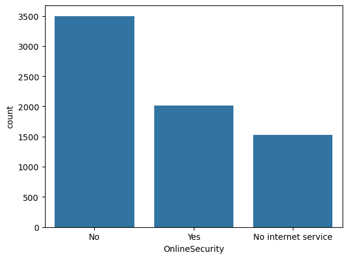

```
                     OnlineSecurity      Ratio
OnlineSecurity
No                             3498  49.666335
Yes                            2019  28.666761
No internet service            1526  21.666903
##########################################
```

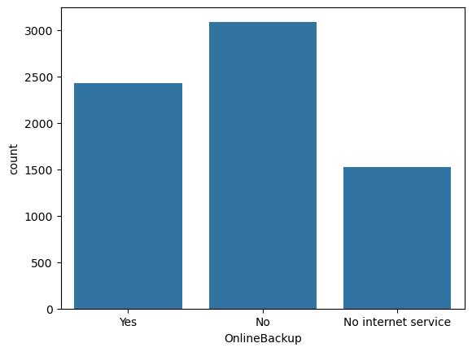

```
                     OnlineBackup      Ratio
OnlineBackup
No                           3088  43.844952
Yes                          2429  34.488144
No internet service          1526  21.666903
##########################################
```

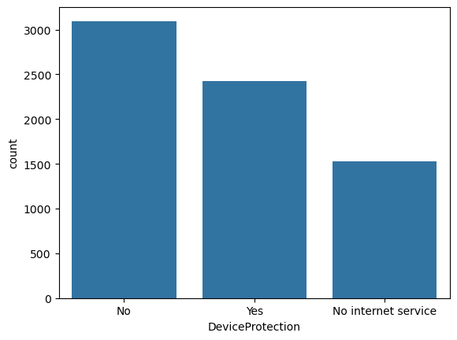

```
                     DeviceProtection      Ratio
DeviceProtection
No                               3095  43.944342
Yes                              2422  34.388755
No internet service              1526  21.666903
##########################################
```

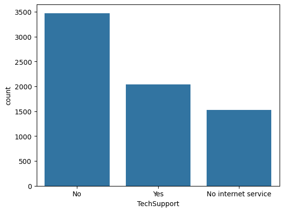

```
                     TechSupport      Ratio
TechSupport
No                          3473  49.311373
Yes                         2044  29.021724
No internet service         1526  21.666903
##########################################
```

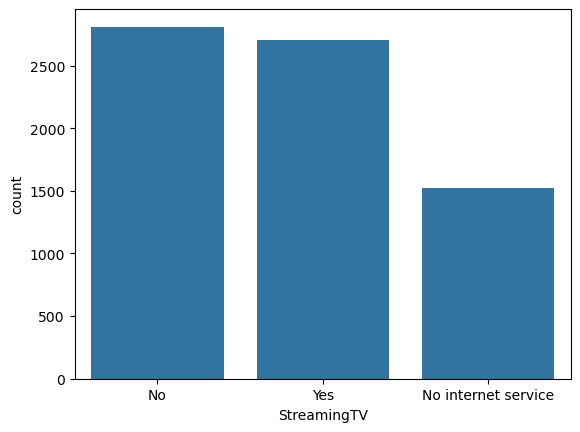

```
                     StreamingTV      Ratio
StreamingTV
No                          2810  39.897771
Yes                         2707  38.435326
No internet service         1526  21.666903
##########################################
```

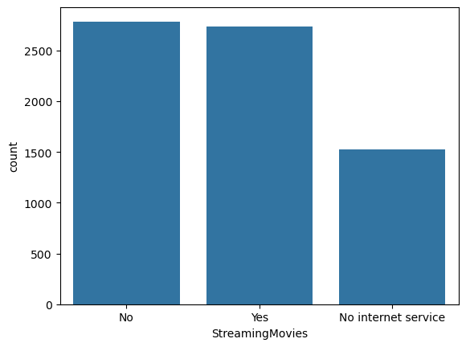

```
                     StreamingMovies      Ratio
StreamingMovies
No                              2785  39.542808
Yes                             2732  38.790288
No internet service             1526  21.666903
##########################################
```

[5 more figures not shown]

```
               SeniorCitizen      Ratio
SeniorCitizen
0                       5901  83.785319
1                       1142  16.214681
##########################################
```

```python
def cat_summary(dataframe, col_name, plot=False):

    if plot:
        sns.countplot(x=dataframe[col_name], data=dataframe)
        plt.show(block=True)
        print(pd.DataFrame({col_name: dataframe[col_name].value_counts(),
                        "Ratio": 100 * dataframe[col_name].value_counts() / len(dataframe)}))
        print("##########################################")


for col in cat_cols:
    cat_summary(df, col,plot=True)
```

## Churen Analyses

```python
df["Churn"].value_counts()
```

```
Churn
No     5174
Yes    1869
Name: count, dtype: int64
```

```python
df["Churn"] = df["Churn"].map({'No':0,'Yes':1})
```

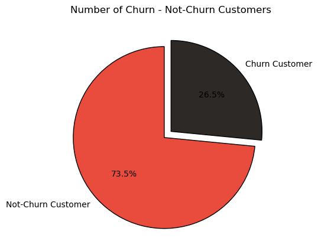

```python
colors = ['#E94B3C','#2D2926']


l = list(df['Churn'].value_counts())
circle = [l[0] / sum(l) * 100,l[1] / sum(l) * 100]

fig = plt.subplots(figsize = (20,5))
plt.pie(circle,labels = ['Not-Churn Customer','Churn Customer'],autopct = '%1.1f%%',startangle = 90,explode = (0.1,0),colors = colors,
       wedgeprops = {'edgecolor' : 'black','linewidth': 1,'antialiased' : True})
plt.title('Churn - Not-Churn %');

plt.title('Number of Churn - Not-Churn Customers');
plt.show()
```

The dataset is unbalanced in a near about 3 : 1 ratio for Not-Churn : Churn customers!

Due to this, predictions will be biased towards Not-Churn customers.

Visualizations will also display this bias!

The Customer Churn Distribution chart and the calculated churn rate provide the following information:

Approximately 73.46% of customers did not churn, indicating that the majority are stable customers.

Approximately 26.54% of customers churned; this is a significant rate and could be a cause for concern for the business.

This churn rate underscores the importance of understanding the factors contributing to customer loss. Businesses can utilize this information to develop strategies aimed at improving customer retention.

## Categorical Variables vs Target Variable (Churn):

Next, let's analyze the distribution of some key categorical variables, especially those that might have a significant impact on churn, like Contract, InternetService, and PaymentMethod.

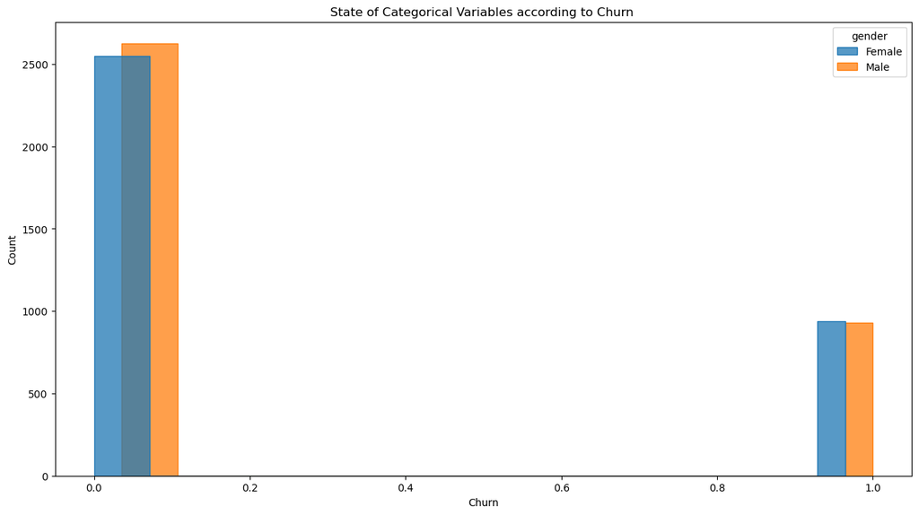

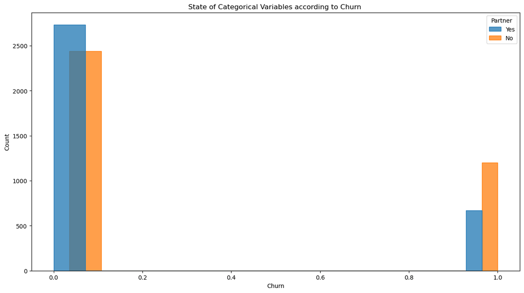

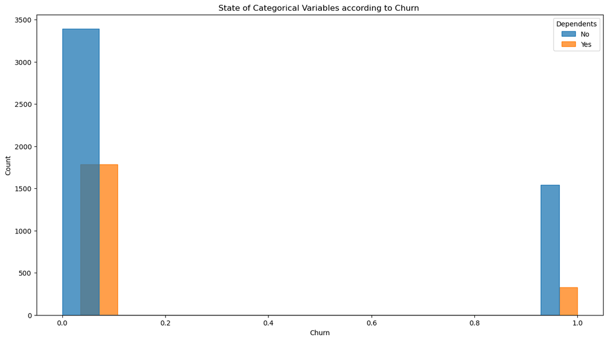

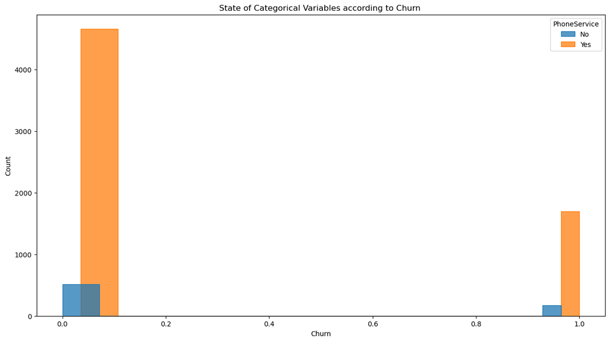

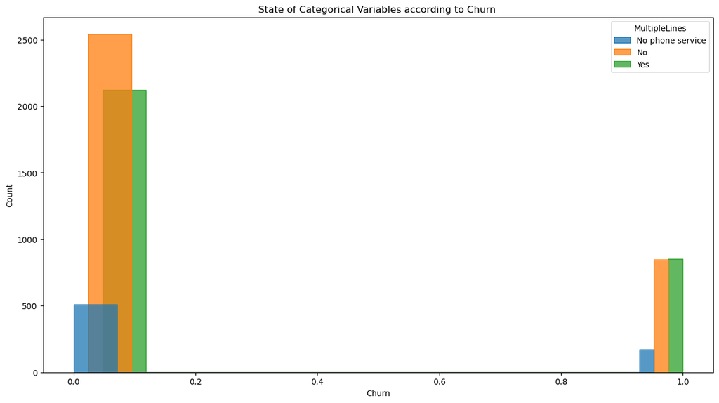

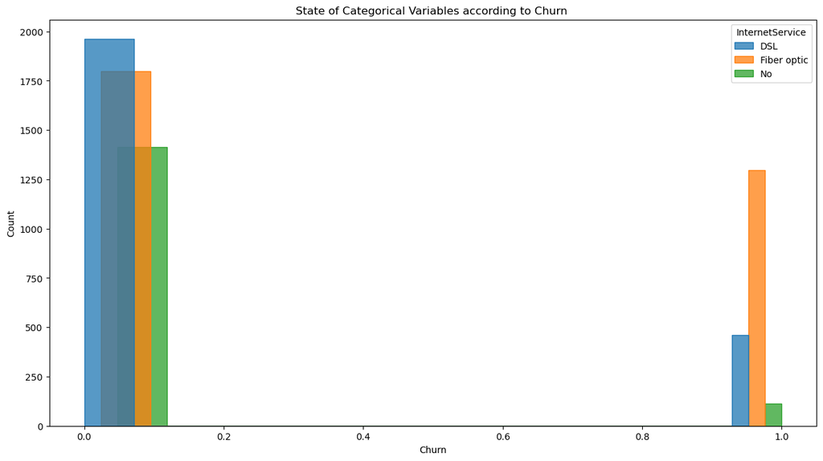

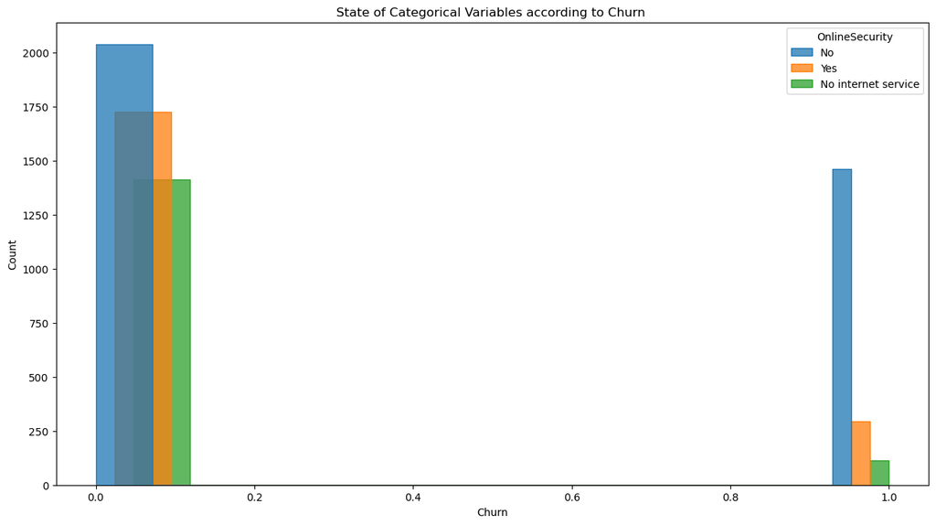

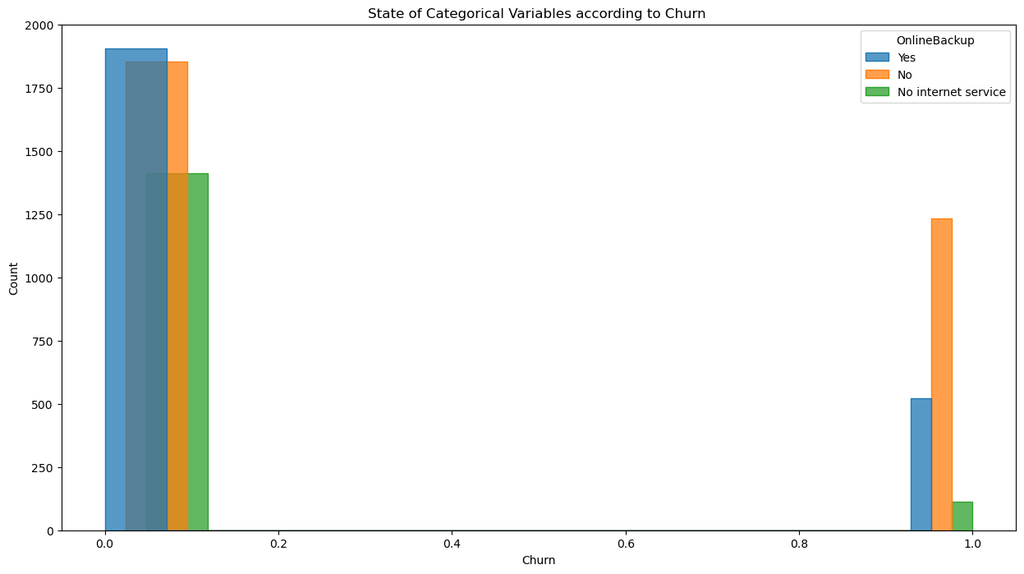

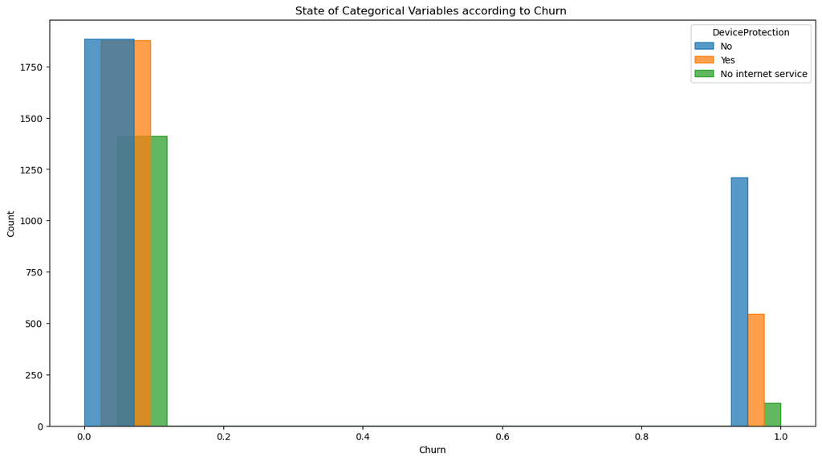

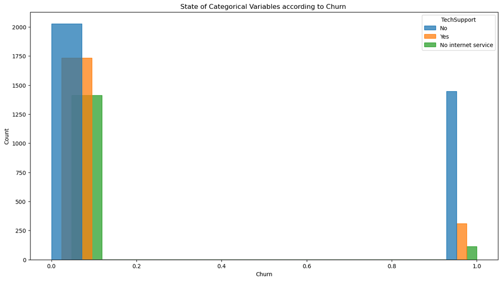

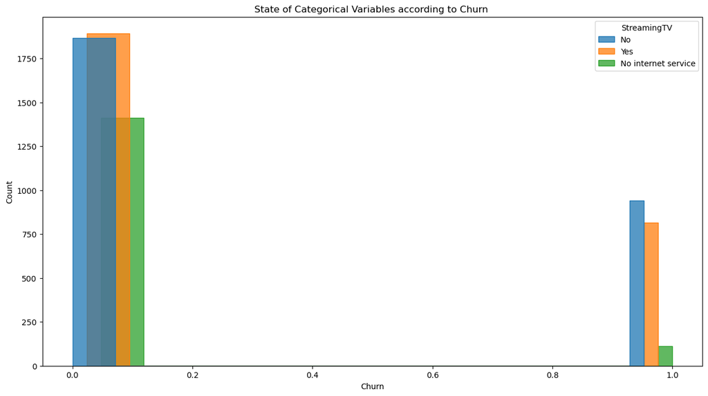

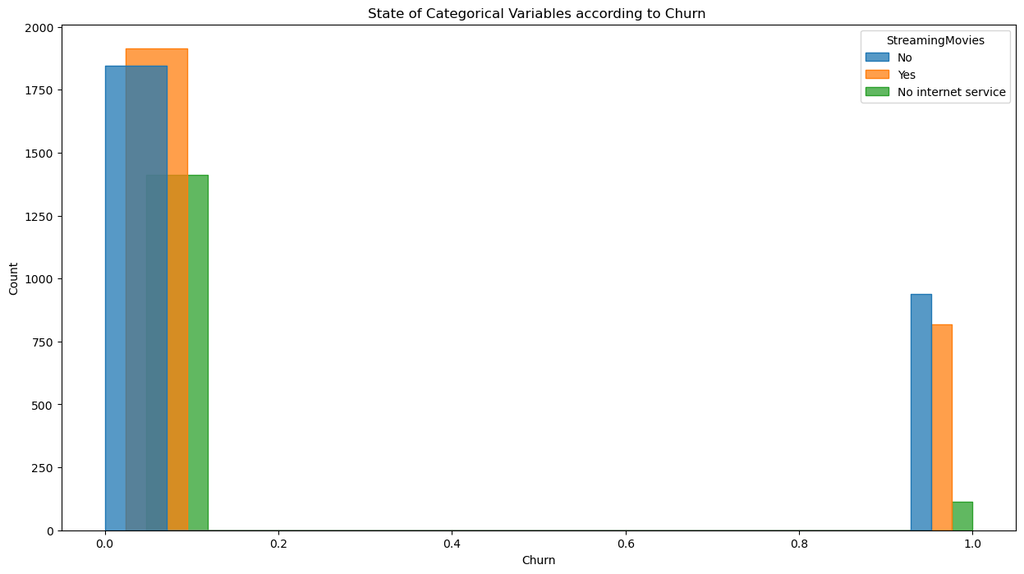

[5 more figures not shown]

```python
def target_vs_category_visual(dataframe,target, categorical_col):
    plt.figure(figsize=(15,8))
    sns.histplot(x=target,hue=categorical_col, data=dataframe,element="step",multiple="dodge")
    plt.title("State of Categorical Variables according to Churn ")
    plt.show()

def target_summary_with_cat(dataframe,target,categorical_col):
    print(pd.DataFrame({"CHURN_MEAN": dataframe.groupby(categorical_col)[target].mean()}))
    print(20*"-")


for col in cat_cols:
    target_vs_category_visual(df,"Churn",col)
```

### Observations:

- Customer churn rates for male and female customers are very similar!
- Likewise, the number of Senior Citizen customers is quite low! Furthermore, we observe a churn rate of **nearly 40% among Senior Citizen customers**. This corresponds to a total of 476 customers out of 1,142 Senior Citizen customers.
- Customers living with a partner experienced **lower churn** compared to those who do not.
- Similarly, the **churn rate is high** for customers who do not have any dependents!
- Regarding Phone Service (despite the absence of such a service), a greater number of customers were retained compared to the number of customers who discontinued their services.
- In the case of Multiple Lines, the churn rate remains the same regardless of whether Multiple Lines are present or not.
- A significant number of customers expressed resistance to the use of fiber-optic cables for the provision of internet services. Conversely, the graph above indicates that customers prefer to use DSL for their Internet Services!
- StreamingTV and StreamingMovies exhibit the same pattern. A large number of customers were lost, regardless of whether or not they were subscribed to StreamingTV and StreamingMovies.
- When it comes to customer service, the OnlineSecurity, OnlineBackup, DeviceProtection, and TechSupport services—as illustrated in the visuals above—are of paramount importance!
- A significant number of customers have switched service providers due to the inadequacy of services featuring the aforementioned capabilities.
- Under the Month-to-Month Contract, customer churn is notably high. The likely reason for this is that customers are testing the various services offered to them—specifically utilizing the one-month service period—in an effort to save money.
- Another contributing factor may be the inconsistency in the overall customer experience regarding internet, broadcasting, and telephone services. Every customer has different priorities; consequently, if the quality of even one of these three services falls short, the entire service subscription is terminated.
- The "Paperless Billing" option appears to be a significant driver of customer attrition. This is likely due to issues related to payments or the receipt of billing statements.
- Customers have clearly expressed their frustration with the Electronic Check payment method. Out of 2,365 invoices paid using electronic checks, a staggering 1,071 customers—nearly half—subsequently dropped out of the service pool specifically because of this payment method. The company must take immediate action to address this issue.
- The Electronic Check payment method must either be discontinued or revamped to be entirely trouble-free and user-friendly.

### Categorical Variables for Churn mean

```python
for col in cat_cols:
    target_summary_with_cat(df,"Churn",col)
```

```
        CHURN_MEAN
gender
Female    0.269209
Male      0.261603
--------------------
         CHURN_MEAN
Partner
No         0.329580
Yes        0.196649
--------------------
            CHURN_MEAN
Dependents
No            0.312791
Yes           0.154502
--------------------
              CHURN_MEAN
PhoneService
No              0.249267
Yes             0.267096
--------------------
                  CHURN_MEAN
MultipleLines
No                  0.250442
No phone service    0.249267
Yes                 0.286099
--------------------
                 CHURN_MEAN
InternetService
DSL                0.189591
Fiber optic        0.418928
No                 0.074050
--------------------
                     CHURN_MEAN
OnlineSecurity
No                     0.417667
No internet service    0.074050
Yes                    0.146112
--------------------
                     CHURN_MEAN
OnlineBackup
```

[output cut: 41 more lines]

```
Bank transfer (automatic)    0.167098
Credit card (automatic)      0.152431
Electronic check             0.452854
Mailed check                 0.191067
--------------------
       CHURN_MEAN
Churn
0             0.0
1             1.0
--------------------
               CHURN_MEAN
SeniorCitizen
0                0.236062
1                0.416813
--------------------
```

## Group 1 : Customer Information :

gender | SeniorCitizen | Partner | Dependents

```python
gender = df[df['Churn'] == 1]['gender'].value_counts()
gender = [gender[0] / sum(gender) * 100, gender[1] / sum(gender) * 100] # Female / Male

seniorcitizen = df[df['Churn'] == 1]['SeniorCitizen'].value_counts()
seniorcitizen = [seniorcitizen[0] / sum(seniorcitizen) * 100,seniorcitizen[1] / sum(seniorcitizen) * 100] # No - Yes

partner = df[df['Churn'] == 1]['Partner'].value_counts()
partner = [partner[0] / sum(partner) * 100,partner[1] / sum(partner) * 100] # No - Yes

dependents = df[df['Churn'] == 1]['Dependents'].value_counts()
dependents = [dependents[0] / sum(dependents) * 100,dependents[1] / sum(dependents) * 100] # No - Yes
```

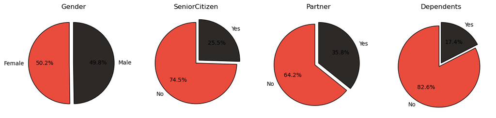

```python
ax,fig = plt.subplots(nrows = 1,ncols = 4,figsize = (15,15))

plt.subplot(1,4,1)
plt.pie(gender,labels = ['Female','Male'],autopct='%1.1f%%',startangle = 90,explode = (0.1,0),colors = colors,
       wedgeprops = {'edgecolor' : 'black','linewidth': 1,'antialiased' : True})
plt.title('Gender');

plt.subplot(1,4,2)
plt.pie(seniorcitizen,labels = ['No', 'Yes'],autopct='%1.1f%%',startangle = 90,explode = (0,0.1),colors = colors,
       wedgeprops = {'edgecolor' : 'black','linewidth': 1,'antialiased' : True})
plt.title('SeniorCitizen');

plt.subplot(1,4,3)
plt.pie(partner,labels = ['No','Yes'],autopct='%1.1f%%',startangle = 90,explode = (0.1,0),colors = colors,
       wedgeprops = {'edgecolor' : 'black','linewidth': 1,'antialiased' : True})
plt.title('Partner');

plt.subplot(1,4,4)
plt.pie(dependents,labels = ['No','Yes'],autopct='%1.1f%%',startangle = 90,explode = (0.1,0),colors = colors,
       wedgeprops = {'edgecolor' : 'black','linewidth': 1,'antialiased' : True})
plt.title('Dependents');
```

### Comments

We observe a clear 50-50 split between male and female customers who switch services. Therefore, the reason for the switch lies in something related to the service itself, or to a specific process to which customers reacted negatively!

Notably, 75% of the customers who were lost are *not* Senior Citizens. This is a crucial piece of information that warrants the company's focused attention!

Customers living alone have been discontinuing their services. According to the "Partners & Dependents" data, an average of 73.4% of the customers who churned were living alone.

## Group 2: Services Subscribed by the Customer :¶

PhoneService | MultipleLines | InternetService | StreamingTV | StreamingMovies |¶

```python
phoneservice = df[df['Churn'] == 1]['PhoneService'].value_counts()
phoneservice = [phoneservice[0] / sum(phoneservice) * 100, phoneservice[1] / sum(phoneservice) * 100] # No - Yes

multiplelines = df[df['Churn'] == 1]['MultipleLines'].value_counts()
multiplelines = [multiplelines[0] / sum(multiplelines) * 100,multiplelines[1] / sum(multiplelines) * 100, multiplelines[2] / sum(multiplelines) * 100] # No - No Phone Service - Yes

internetservice = df[df['Churn'] == 1]['InternetService'].value_counts()
internetservice = [internetservice[0] / sum(internetservice) * 100,internetservice[1] / sum(internetservice) * 100, internetservice[2] / sum(internetservice) * 100] # DSL - Fiber Optic - No

streamingtv = df[df['Churn'] == 1]['StreamingTV'].value_counts()
streamingtv = [streamingtv[0] / sum(streamingtv) * 100,streamingtv[1] / sum(streamingtv) * 100, streamingtv[2] / sum(streamingtv) * 100] # No - No Internet Service - Yes

streamingmovies = df[df['Churn'] == 1]['StreamingMovies'].value_counts()
streamingmovies = [streamingmovies[0] / sum(streamingmovies) * 100,streamingmovies[1] / sum(streamingmovies) * 100, streamingmovies[2] / sum(streamingmovies) * 100] # No - No Internet Service - Yes
```

[figure not shown]

[figure not shown]

```python
ax,fig = plt.subplots(nrows = 1,ncols = 2,figsize = (8,8))

plt.subplot(1,2,1)
plt.pie(phoneservice,labels = ['No', 'Yes'],autopct='%1.1f%%',startangle = 90,explode = (0.1,0),colors = colors,
       wedgeprops = {'edgecolor' : 'black','linewidth': 1,'antialiased' : True})
plt.title('PhoneService');

plt.subplot(1,2,2)
plt.pie(multiplelines,labels = ['No','No Phone Service','Yes'],autopct='%1.1f%%',startangle = 90,explode = (0.1,0,0.1),colors = colors,
       wedgeprops = {'edgecolor' : 'black','linewidth': 1,'antialiased' : True})
plt.title('MultipleLines');

ax,fig = plt.subplots(nrows = 1,ncols = 3,figsize = (12,12))

plt.subplot(1,3,1)
plt.pie(internetservice,labels = ['DSL', 'Fiber Optic','No'],autopct='%1.1f%%',startangle = 90,explode = (0.1,0,0.1),colors = colors,
       wedgeprops = {'edgecolor' : 'black','linewidth': 1,'antialiased' : True})
plt.title('InternetService');

plt.subplot(1,3,2)
plt.pie(streamingtv,labels = ['No', 'No Internet Service','Yes'],autopct='%1.1f%%',startangle = 90,explode = (0.1,0,0.1),colors = colors,
       wedgeprops = {'edgecolor' : 'black','linewidth': 1,'antialiased' : True})
plt.title('StreamingTV');

plt.subplot(1,3,3)
plt.pie(streamingmovies,labels = ['No', 'No Internet Service','Yes'],autopct='%1.1f%%',startangle = 90,explode = (0.1,0,0.1),colors = colors,
       wedgeprops = {'edgecolor' : 'black','linewidth': 1,'antialiased' : True})
plt.title('StreamingMovies');
```

## Group 3: Services Subscribed by the Customer

OnlineSecurity | OnlineBackup | DeviceProtection | TechSupport

```python
onlinesecurity = df[df['Churn'] == 1]['OnlineSecurity'].value_counts()
onlinesecurity = [onlinesecurity[0] / sum(onlinesecurity) * 100,onlinesecurity[1] / sum(onlinesecurity) * 100, onlinesecurity[2] / sum(onlinesecurity) * 100] # No - No Internet Service - Yes

onlinebackup = df[df['Churn'] == 1]['OnlineBackup'].value_counts()
onlinebackup = [onlinebackup[0] / sum(onlinebackup) * 100,onlinebackup[1] / sum(onlinebackup) * 100, onlinebackup[2] / sum(onlinebackup) * 100] # No - No Internet Service - Yes

deviceprotection = df[df['Churn'] == 1]['DeviceProtection'].value_counts()
deviceprotection = [deviceprotection[0] / sum(deviceprotection) * 100,deviceprotection[1] / sum(deviceprotection) * 100, deviceprotection[2] / sum(deviceprotection) * 100] # No - No Internet Service - Yes

techsupport = df[df['Churn'] == 1]['TechSupport'].value_counts()
techsupport = [techsupport[0] / sum(techsupport) * 100,techsupport[1] / sum(techsupport) * 100, techsupport[2] / sum(techsupport) * 100] # No - No Internet Service - Yes
```

[figure not shown]

```python
ax,fig = plt.subplots(nrows = 1,ncols = 4,figsize = (15,15))

plt.subplot(1,4,1)
plt.pie(onlinesecurity,labels = ['No', 'No Internet Service','Yes'],autopct='%1.1f%%',startangle = 90,explode = (0.1,0,0.1),colors = colors,
       wedgeprops = {'edgecolor' : 'black','linewidth': 1,'antialiased' : True})
plt.title('OnlineSecurity');

plt.subplot(1,4,2)
plt.pie(onlinebackup,labels = ['No', 'No Internet Service','Yes'],autopct='%1.1f%%',startangle = 90,explode = (0.1,0.1,0),colors = colors,
       wedgeprops = {'edgecolor' : 'black','linewidth': 1,'antialiased' : True})
plt.title('OnlineBackup');

plt.subplot(1,4,3)
plt.pie(deviceprotection,labels = ['No', 'No Internet Service','Yes'],autopct='%1.1f%%',startangle = 90,explode = (0.1,0,0.1),colors = colors,
       wedgeprops = {'edgecolor' : 'black','linewidth': 1,'antialiased' : True})
plt.title('DeviceProtection');

plt.subplot(1,4,4)
plt.pie(techsupport,labels = ['No', 'No Internet Service','Yes'],autopct='%1.1f%%',startangle = 90,explode = (0.1,0,0.1),colors = colors,
       wedgeprops = {'edgecolor' : 'black','linewidth': 1,'antialiased' : True})
plt.title('TechSupport');
```

The pie charts above highlight the importance of providing Online Security, Online Backup, Device Protection, and Tech Support, as an average of 71.6% of customers discontinue their services due to the lack of these features!

## Group 4 : Contract | PaperlessBilling | PaymentMethod |¶

```python
contract = df[df['Churn'] == 1]['Contract'].value_counts()
contract = [contract[0] / sum(contract) * 100, contract[1] / sum(contract) * 100, contract[2] / sum(contract) * 100] # Month-to-month - One year - Two year

paperlessbilling = df[df['Churn'] == 1]['PaperlessBilling'].value_counts()
paperlessbilling = [paperlessbilling[0] / sum(paperlessbilling) * 100,paperlessbilling[1] / sum(paperlessbilling) * 100] # No - Yes

paymentmethod = df[df['Churn'] == 1]['PaymentMethod'].value_counts()
paymentmethod = [paymentmethod[0] / sum(paymentmethod) * 100, paymentmethod[1] / sum(paymentmethod) * 100,
            paymentmethod[2] / sum(paymentmethod) * 100, paymentmethod[3] / sum(paymentmethod) * 100]
```

[figure not shown]

```python
ax,fig = plt.subplots(nrows = 1,ncols = 3,figsize = (12,12))

plt.subplot(1,3,1)
plt.pie(contract,labels = ['Month-to-month','One year','Two year'],autopct='%1.1f%%',startangle = 90,explode = (0.1,0.1,0.1),colors = colors,
       wedgeprops = {'edgecolor' : 'black','linewidth': 1,'antialiased' : True})
plt.title('Contract');

plt.subplot(1,3,2)
plt.pie(paperlessbilling,labels = ['No', 'Yes'],autopct='%1.1f%%',startangle = 90,explode = (0.1,0),colors = colors,
       wedgeprops = {'edgecolor' : 'black','linewidth': 1,'antialiased' : True})
plt.title('PaperlessBilling');

plt.subplot(1,3,3)
plt.pie(paymentmethod,labels = ['Bank Transfer (automatic)','Credit Card (automatic)','Electronic check','Mailed check'],autopct='%1.1f%%',startangle = 90,explode = (0.1,0,0.1,0),colors = colors,
       wedgeprops = {'edgecolor' : 'black','linewidth': 1,'antialiased' : True})
plt.title('PaymentMethod');
```

### Comment

- Contract duration—specifically month-to-month terms—holds the dominant share when it comes to a massive customer churn rate of 88.6%!
- Paperless billing appears to be unpopular among customers!
- Electronic checks must definitely be eliminated, as they account for 57.3% of the churn. This is followed by Checks by Mail, Bank Transfers (automated), and Credit Cards (automated)!